# Lecture 1 Exercises

## Short Questions

1. What is the difference between a list and an array?
2. Consider the list

`list_colors = ["red","yellow","green"]`

What is the output of `list_colors[0]` and  
`list_colors[1]`?

3. How do you concatenate two strings?
4. What does the error "not defined" mean?
5. What does the error "could not be broadcast" mean?
6. How do you compute the median of an array?

```python
# Write your answers here as comments:

# 1. A list is an ordered set of values that can be made up of any data type.
# An array is similar to a list, but it usually refers to a collection of numbers
# making up a vector that can be used for mathematical operations.

# 2. The command produces an output of the first (red) and 2nd (yellow) items in the list.
list_colors = ['red', 'yellow', 'green']
list_colors[1]

# 3. You can use the + symbol to concatenate two strings together.

# 4. "Not defined" means that the user hasn't defined a variable or function before
# trying to use it. Python doesn't recognize what the user is trying to do.

# 5. Could not be broadcast means two arrays are not the same shape and therefore the command can't be executed.

# 6. To compute the median of an array, you can use the numpy function np.median(array_name).
```

```
'yellow'
```

## Long Questions

(a) Import the pandas, matplotlib, and numpy packages

```python
# Write your own code

import pandas as pd
import matplotlib.pyplot as plt
import numpy as np
```

(b) Open the dataset "worldbank_wdi_2019.csv"  
in the "data" folder

- Read it as a pandas object called "wdi"
- Note: This is a subset of the World Development Indicators for 2019
- Each observation represents a different country

```python
# Write your own code


wdi = pd.read_csv("data/worldbank_wdi_2019.csv")
```

(c) Browse the dataset and manually create  
a list of variable names

```python
# Write your own code

# Create a list, e.g. "variable_names = [ "name1", "name2", "name3" ]"
# Manually type the names of the variables
# If you're viewing the dataset from the VS-Code "Variables" tool, you'll
# see an extra column "index". Do not include this in your list.


variable_names = ['year', 'country_name', 'life_expectancy', 'gdp_per_capita_usd']
```

(d) Compute descriptive statistics for the fourth  
variable in the dataset

- One way to do this is:

wdi["gdp_per_capita_usd"].describe()

- Do something similar, but with the list you created above.
- Substitute "gdp_per_capita_usd" with a command that  
  automatically extracts the fourth element in the list

```python
# Write your own code

# Remember that the numbering in Python starts at zero
# For example:
# list_colors = ["red","green","yellow"]
# list_colors[2] will output "yellow"

wdi[variable_names[3]].describe()
```

```
count       255.000000
mean      17230.949757
std       25792.183785
min         216.972968
25%        2186.046581
50%        6837.717826
75%       19809.323135
max      199377.481800
Name: gdp_per_capita_usd, dtype: float64
```

(e) Show a scatter plot that shows "gdp_per_capita_usd"  
in the x-axis and "lifexpectancy" in the y-axis. Label the axes.

```
<function matplotlib.pyplot.show(close=None, block=None)>
```

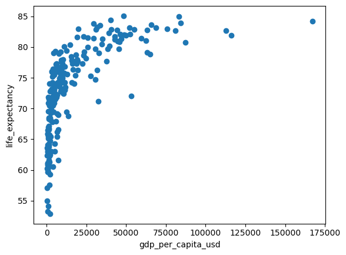

```python
# Write your own code

plt.scatter(x = wdi[variable_names[3]], y = wdi[variable_names[2]])
plt.xlabel(variable_names[3])
plt.ylabel(variable_names[2])
plt.show
```

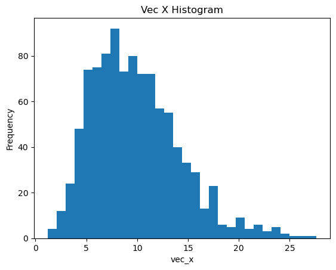

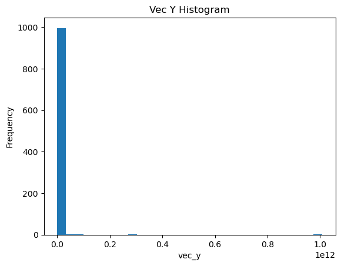

```python
# Write your own code
# generate vec_x from a chi square distribution with 10 degrees of freedom
vec_x = np.random.chisquare(df=10, size=1000)
vec_y = np.exp(vec_x) + 2*vec_x + 5


plt.hist(x = vec_x, bins=30)
plt.xlabel('vec_x')
plt.ylabel('Frequency')
plt.title("Vec X Histogram")
plt.show()

plt.hist(x = vec_y, bins=30)
plt.xlabel('vec_y')
plt.ylabel('Frequency')
plt.title("Vec Y Histogram")
plt.show()
```

(g) Research online how to create an array with  
`size = 1000` entries, with all entries equal to one.

- Create a new matrix, `X_mat` that appends a  
  vector with only ones and "vec_x" from question (f) to form  
  a matrix with two columns and 1000 rows
- Compute $(X_{mat}'X_{mat})^{-1}$

```python
# Write your own code

ones_vec = np.ones(1000)
X_mat = np.column_stack((ones_vec, vec_x))
XtX_inv = np.linalg.inv(X_mat.T @ X_mat)
print(XtX_inv)

XtX_inv
```

```
[[ 6.22779367e-03 -5.30642939e-04]
 [-5.30642939e-04  5.38624794e-05]]
```

```
array([[ 6.22779367e-03, -5.30642939e-04],
       [-5.30642939e-04,  5.38624794e-05]])
```